# HW4 ds 303

Alexis Maldonado

9/18/2023

```r
prostate = read.table("/Users/alexrubio/Downloads/Ds 303/prostate.data",header=TRUE)
```

1.a

```r
library(leaps)

prostate = na.omit(prostate)
best.model = regsubsets(lpsa -train ~., data = prostate ,nbest=1,nvmax=8)
summary(best.model)
```

```
## Subset selection object
## Call: regsubsets.formula(lpsa - train ~ ., data = prostate, nbest = 1,
##     nvmax = 8)
## 8 Variables  (and intercept)
##         Forced in Forced out
## lcavol      FALSE      FALSE
## lweight     FALSE      FALSE
## age         FALSE      FALSE
## lbph        FALSE      FALSE
## svi         FALSE      FALSE
## lcp         FALSE      FALSE
## gleason     FALSE      FALSE
## pgg45       FALSE      FALSE
## 1 subsets of each size up to 8
## Selection Algorithm: exhaustive
##          lcavol lweight age lbph svi lcp gleason pgg45
## 1  ( 1 ) "*"    " "     " " " "  " " " " " "     " "
## 2  ( 1 ) "*"    "*"     " " " "  " " " " " "     " "
## 3  ( 1 ) "*"    "*"     " " " "  "*" " " " "     " "
## 4  ( 1 ) "*"    "*"     "*" " "  "*" " " " "     " "
## 5  ( 1 ) "*"    "*"     "*" "*"  "*" " " " "     " "
## 6  ( 1 ) "*"    "*"     "*" "*"  "*" " " "*"     " "
## 7  ( 1 ) "*"    "*"     "*" "*"  "*" "*" "*"     " "
## 8  ( 1 ) "*"    "*"     "*" "*"  "*" "*" "*"     "*"
```

```r
val.errors = rep(NA,8)
for(i in 1:8){
  test.mat = model.matrix(lpsa - train~.,data=prostate)

  coef.m = coef(best.model,id=i)

  pred = test.mat[,names(coef.m)]%*%coef.m
  val.errors[i] = mean((prostate$lpsa-pred)^2)
}

regfitt = regsubsets(lpsa- train~., data = prostate, nbest = 1, nvmax = 8)
regfitt.sum = summary(regfitt)

n = dim(prostate)[1]
p = rowSums(regfitt.sum$which)
adjr2 = regfitt.sum$adjr2
cp = regfitt.sum$cp
rss = regfitt.sum$rss
AIC = n*log(rss/n) + 2*(p)
BIC = n*log(rss/n) + (p)*log(n)

cbind(AIC,BIC,adjr2,cp)
```

```
##         AIC        BIC     adjr2        cp
## 1 -15.22388 -10.074456 0.4715094 20.686465
## 2 -22.28252 -14.558383 0.5135087 12.550180
## 3 -25.75794 -15.459092 0.5352653  8.866930
## 4 -27.98474 -15.111181 0.5502453  6.693933
## 5 -29.80644 -14.358177 0.5628692  5.074257
## 6 -29.48088 -11.457907 0.5655764  5.532713
## 7 -28.00967  -7.411979 0.5630836  7.051402
## 8 -26.06631  -2.893910 0.5583766  9.000000
```

```r
which.min(AIC)
```

```
## 5
## 5
```

```r
which.min(BIC)
```

```
## 3
## 3
```

```r
which.max(adjr2)
```

```
## [1] 6
```

```r
which.min(cp)
```

```
## [1] 5
```

```r
coef(regfitt,5)
```

```
## (Intercept)      lcavol     lweight         age        lbph         svi
##  0.60141170  0.59266210  0.61761909 -0.03144412  0.13116073  0.64618937
```

```r
coef(regfitt,3)
```

```
## (Intercept)      lcavol     lweight         svi
##  -1.4843125   0.5600597   0.6584660   0.5836455
```

```r
coef(regfitt,6)
```

```
## (Intercept)      lcavol     lweight         age        lbph         svi
## -0.45121360  0.55534204  0.66721437 -0.03477097  0.12392795  0.60555832
##     gleason
##  0.16956842
```

While AIC and cp agree on 5 the other 2 had different choices, because the two chose the 5th on and one 6th i would probably go with the 5th since it seems to be with a good range not too little but not too much.

1.b

```r
n = dim(prostate)[1]

train <- subset(prostate, train == TRUE)[, 1:9]
test <- subset(prostate, train == FALSE)[, 1:9]

val.errors = matrix(NA,9)


best.fit = regsubsets(lpsa ~. ,data=train,nbest=1,nvmax=9)

  for(i in 1:8){
    test.mat = model.matrix(lpsa~.,data=train)

    coef.m = coef(best.fit,id=i)

    pred = test.mat[,names(coef.m)]%*%coef.m
    val.errors[i] = mean((test$lpsa-pred)^2)
  }
val.errors
```

```
##           [,1]
##  [1,] 1.648643
##  [2,] 1.900494
##  [3,] 1.957761
##  [4,] 1.963142
##  [5,] 1.964930
##  [6,] 2.013556
##  [7,] 2.023126
##  [8,] 2.028625
##  [9,]       NA
```

```r
full.reg = regsubsets(lpsa~.,data=prostate,nvmax=9,nbest=1)
coef(full.reg,1)
```

```
## (Intercept)      lcavol
##   1.5072975   0.7193204
```

1.c

```r
k = 10
folds = sample(1:k,nrow(prostate),replace=TRUE)

val.errors = matrix(NA,8)

for(j in 1:k){
  test = prostate[folds==j,]
  train = prostate[folds!=j,]

  best.fit = regsubsets(lpsa ~. -train,data=train,nbest=1,nvmax=8)

  for(i in 1:8){
    test.mat = model.matrix(lpsa~.-train,data=test)

    coef.m = coef(best.fit,id=i)

    pred = test.mat[,names(coef.m)]%*%coef.m
    val.errors[i] = mean((test$lpsa-pred)^2)
  }
}

val.errors
```

```
##           [,1]
## [1,] 0.4588497
## [2,] 0.5040716
## [3,] 0.5020962
## [4,] 0.4924112
## [5,] 0.5092844
## [6,] 0.6252219
## [7,] 0.5880471
## [8,] 0.5928645
```

```r
full.reg = regsubsets(lpsa~. -train,data=prostate,nvmax=8,nbest=1)
coef(full.reg,2)
```

```
## (Intercept)      lcavol     lweight
##  -0.8134373   0.6515421   0.6647215
```

2.a

```r
set.seed(1)

p = 20
n = 1000
X = matrix(rnorm(n * p), nrow = n)
error <- rnorm(1000,0,1)
beta = c(1, 0, 0, 0, 2, 0, 0, 0, 0, 3, 0, 0, 0, 0, 4, 0, 0, 0, 0, 5)
Y = X%*%beta + error
data1 = data.frame(Y = Y, X)
```

2.b

```r
train_index = sample(1:1000,900,rep=FALSE)

train = data1[train_index,]
test = data1[-train_index,]
```

2.c

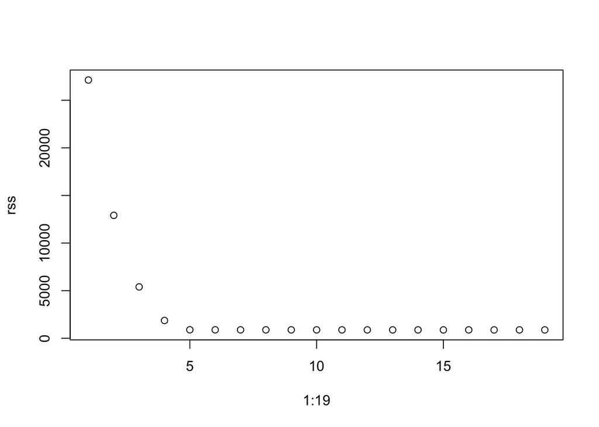

```r
bestfit = regsubsets(Y ~.,data=train,nbest=1,nvmax=19)
bestfit.sum = summary(bestfit)
rss = bestfit.sum$rss
plot(1:19, rss)
```

```r
bestfit.sum$rss
```

```
##  [1] 27124.7012 12909.2867  5394.8716  1869.2267   891.6009   888.0861
##  [7]   885.7338   884.5471   883.5592   882.7702   882.1016   881.5248
## [13]   881.0274   880.6968   880.5209   880.3570   880.2588   880.2152
## [19]   880.1875
```

```r
bestfit.sum$rss
```

```
##  [1] 27124.7012 12909.2867  5394.8716  1869.2267   891.6009   888.0861
##  [7]   885.7338   884.5471   883.5592   882.7702   882.1016   881.5248
## [13]   881.0274   880.6968   880.5209   880.3570   880.2588   880.2152
## [19]   880.1875
```

2.d

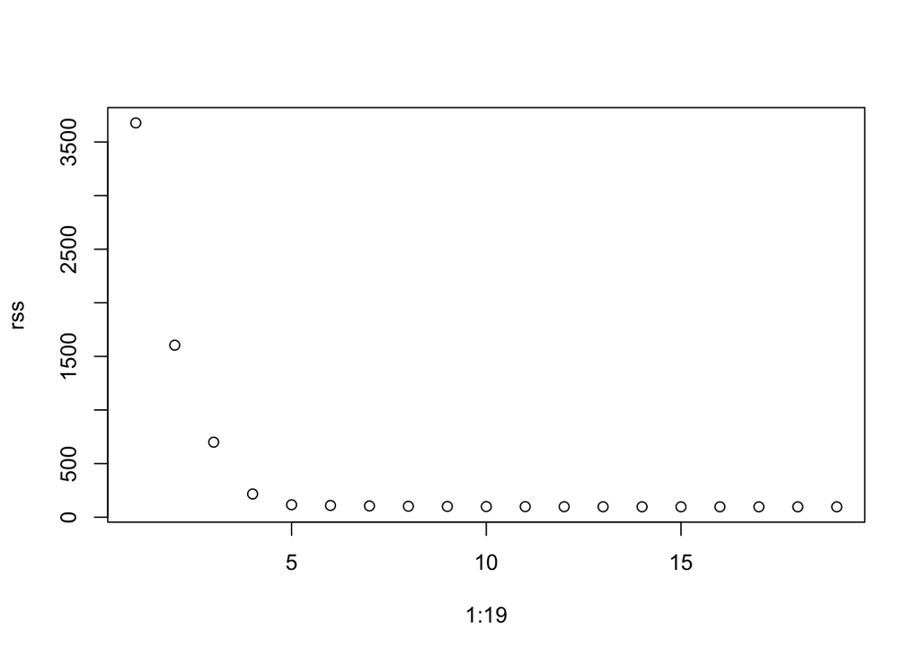

```r
bestfitt = regsubsets(Y ~.,data=test,nbest=1,nvmax=19)
bestfitt.sum = summary(bestfitt)
rss = bestfitt.sum$rss
plot(1:19, rss)
```

2.e 19 has the smallest mse.

2.f

```r
real = regsubsets(Y ~.,data= data1,nbest=1,nvmax=19)
reall = summary(real)
bestfitt.sum$rss
```

```
##  [1] 3677.71893 1604.63844  699.64389  216.60939  116.19956  109.61009
##  [7]  105.10633  102.19092  100.40433   99.31116   98.59291   98.07489
## [13]   97.51778   97.27129   97.09384   97.02695   96.94740   96.89580
## [19]   96.84079
```

```r
reall$rss
```

```
##  [1] 30812.332 14532.934  6108.116  2096.193  1015.345  1011.289  1009.306
##  [8]  1007.897  1006.892  1005.911  1005.158  1004.484  1004.119  1003.864
## [15]  1003.617  1003.428  1003.371  1003.314  1003.274
```

3.a K fold cross validation is implemented by divide the data into groups and allowing each fold to take turns being the test set, then running it through the proces and collecting the test mse.

3.b The disadvantages to the validation set approach is we cant leverage all the data and the splits are inconsistent.

The advantages of loocv is that we are able to go through all the data but a big disadvantage is the it is really computationally expansive

3.c

```r
set.seed(1)
x = rnorm(100)
error = rnorm(100,0,1)
y = x - 2 * x^2 + error
data = data.frame(Y = y, x)
```

3.d

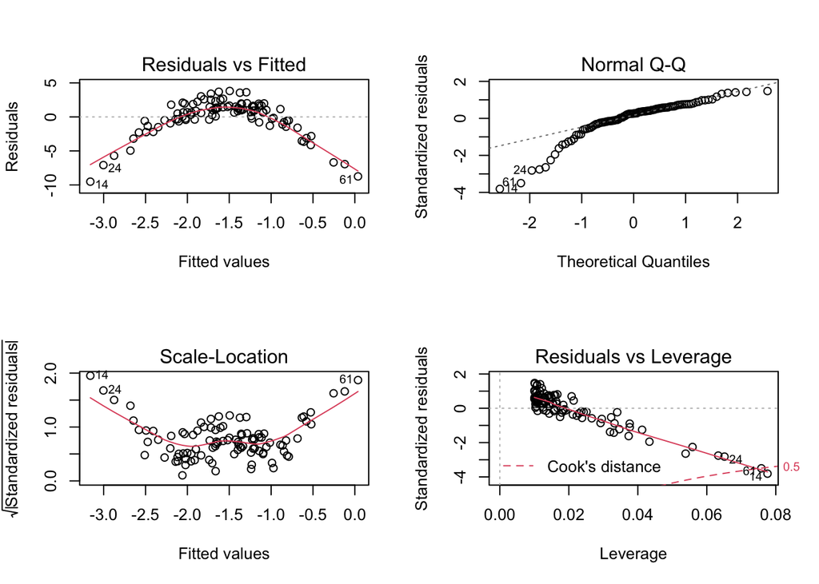

```r
model = lm(y ~ x)
par(mfrow=c(2,2))
plot(model)
```

3.e

```r
MSE_M1 = numeric(100)
MSE_M2 = numeric(100)
MSE_M3 = numeric(100)
MSE_M4 = numeric(100)
for(i in 1:100){
  test = data[i,]
  train = data[-i,]
  data


  M1 = lm(y ~ x,data=data)
  M2 = lm(y ~ poly(x,2),data=data)
  M3 = lm(y ~ poly(x,3),data=data)
  M4 = lm(y ~ poly(x,4),data=data)

  M1_y = predict(M1,newdata=test)
  M2_y = predict(M2,newdata=test)
  M3_y = predict(M3,newdata=test)
  M4_y = predict(M4,newdata=test)

  MSE_M1 = (test$y - M1_y)^2
  MSE_M2 = (test$y - M2_y)^2
  MSE_M3 = (test$y - M3_y)^2
  MSE_M4 = (test$y - M4_y)^2
}

# linear models, use PRESS
PRESS <- function(model,n) {
    i <- residuals(model)/(1 - lm.influence(model)$hat)
    sum(i^2)/n
}


PRESS(M1,n)
```

```
## [1] 0.7288162
```

```r
PRESS(M2,n)
```

```
## [1] 0.09374236
```

```r
PRESS(M3,n)
```

```
## [1] 0.09566218
```

```r
PRESS(M4,n)
```

```
## [1] 0.09539049
```

3.f

```r
set.seed(111)
for(i in 1:n){
  test = data[i,]
  train = data[-i,]


  M1 = lm(y ~ x,data=data)
  M2 = lm(y ~ poly(x,2),data=data)
  M3 = lm(y ~ poly(x,3),data=data)
  M4 = lm(y ~ poly(x,4),data=data)

  M1_y = predict(M1,newdata=test)
  M2_y = predict(M2,newdata=test)
  M3_y = predict(M3,newdata=test)
  M4_y = predict(M4,newdata=test)

  MSE_M1[i] = (test$y - M1_y)^2
  MSE_M2[i] = (test$y - M2_y)^2
  MSE_M3[i] = (test$y - M3_y)^2
  MSE_M4[i] = (test$y - M4_y)^2
}

# linear models, use PRESS
PRESS <- function(model,n) {
    i <- residuals(model)/(1 - lm.influence(model)$hat)
    sum(i^2)/n
}


PRESS(M1,n)
```

```
## [1] 0.7288162
```

```r
PRESS(M2,n)
```

```
## [1] 0.09374236
```

```r
PRESS(M3,n)
```

```
## [1] 0.09566218
```

```r
PRESS(M4,n)
```

```
## [1] 0.09539049
```

3.h Yes I agree with the conclusions that we were able to draw based on the cross validation results.

4.a True, because each one of those looks at different things so you are not guaranteed that they will choose the same model.

4.b True, the rss in a reduced model will always be bigger or equal to the rss in a full model.

4.c True, the rss in a reduced model will always be bigger or equal to the rss in a full model.

a Base on summaries of the best.model code we have done I beleive that it is true the the next model will include the variables in the model before since they probably have more significance hence why they were chosen first.

b The advantage of using BIC and Aic over MSE is to be able to to test multiple models and determine which one is better while MSE allows you to know how good your model is.

c I would disagree since we dont know how many variables there are we should not assume that it is not meaningful at all.